# Covid- 19 Data Analysis using Holt

Importing all the necessary libraries required.

```python
import numpy as np
import pandas as pd
import seaborn as sns
import matplotlib.pyplot as plt
import datetime as dt
from datetime import timedelta

import plotly.offline as py
import plotly.graph_objs as go
import cufflinks as cf
import plotly.express as px
import scipy
import chart_studio

%matplotlib inline
sns.set_style('whitegrid')
import warnings
warnings.filterwarnings('ignore')
```

Loading the dataset into the notebook

```python
df= pd.read_excel('Covid_19_Data.xlsx')
print("Shape of Dataframe : {}".format(df.shape))
df
```

```
Shape of Dataframe : (18327, 8)
```

|  | Sl_No | Observation_Date | Province/State | Country/Region | Last_Update | Confirmed | Deceased | Cured |
| --- | --- | --- | --- | --- | --- | --- | --- | --- |
| 0 | 1 | 2020-01-22 | Anhui | Mainland China | 2020-01-22 17:00:00 | 1 | 0 | 0 |
| 1 | 2 | 2020-01-22 | Beijing | Mainland China | 2020-01-22 17:00:00 | 14 | 0 | 0 |
| 2 | 3 | 2020-01-22 | Chongqing | Mainland China | 2020-01-22 17:00:00 | 6 | 0 | 0 |
| 3 | 4 | 2020-01-22 | Fujian | Mainland China | 2020-01-22 17:00:00 | 1 | 0 | 0 |
| 4 | 5 | 2020-01-22 | Gansu | Mainland China | 2020-01-22 17:00:00 | 0 | 0 | 0 |
| ... | ... | ... | ... | ... | ... | ... | ... | ... |
| 18322 | 18323 | 2020-04-24 | Wyoming | US | 2020-04-25 06:31:19 | 473 | 7 | 0 |
| 18323 | 18324 | 2020-04-24 | Xinjiang | Mainland China | 2020-04-25 06:31:19 | 76 | 3 | 73 |
| 18324 | 18325 | 2020-04-24 | Yukon | Canada | 2020-04-25 06:31:19 | 11 | 0 | 0 |
| 18325 | 18326 | 2020-04-24 | Yunnan | Mainland China | 2020-04-25 06:31:19 | 185 | 2 | 180 |
| 18326 | 18327 | 2020-04-24 | Zhejiang | Mainland China | 2020-04-25 06:31:19 | 1268 | 1 | 1256 |

18327 rows × 8 columns

Checking whether any null values are present in the dataset or not

```python
df.isnull().any()
```

```
Sl_No               False
Observation_Date    False
Province/State       True
Country/Region      False
Last_Update         False
Confirmed           False
Deceased            False
Cured               False
dtype: bool
```

```python
df.isnull().sum()
df.drop(['Province/State'],axis=1,inplace=True)
```

Chcking the datatypes of data

```python
df.dtypes
```

```
Sl_No                        int64
Observation_Date    datetime64[ns]
Country/Region              object
Last_Update         datetime64[ns]
Confirmed                    int64
Deceased                     int64
Cured                        int64
dtype: object
```

Removing unnecessary columns from the dataset

```python
df.drop(['Sl_No','Last_Update'],axis=1,inplace=True)
df.head()
```

|  | Observation_Date | Country/Region | Confirmed | Deceased | Cured |
| --- | --- | --- | --- | --- | --- |
| 0 | 2020-01-22 | Mainland China | 1 | 0 | 0 |
| 1 | 2020-01-22 | Mainland China | 14 | 0 | 0 |
| 2 | 2020-01-22 | Mainland China | 6 | 0 | 0 |
| 3 | 2020-01-22 | Mainland China | 1 | 0 | 0 |
| 4 | 2020-01-22 | Mainland China | 0 | 0 | 0 |

## Worldwide Status of Covid-19

Grouping the data together based on the Observation date. Taking the aggregate sum of Confirmed,Cured and Deceased cases in order to analyze worldwide status of the pandemic.

```python
datewise = df.groupby(["Observation_Date"]).agg({"Confirmed":"sum","Cured":"sum","Deceased":"sum"})
```

Calculating the total number of active and closed cases.

```python
print("Worldwide Status")
print("________________")
print("Total number of Confirmed cases = ",datewise["Confirmed"].iloc[-1])
print("Total number of Cured cases = ",datewise["Cured"].iloc[-1])
print("Total number of Deceased cases = ",datewise["Deceased"].iloc[-1])
print("Total number of Active cases = ",(datewise["Confirmed"].iloc[-1]-datewise["Cured"].iloc[-1]-datewise["Deceased"].iloc[-1]))
print("Total number of Closed cases = ",(datewise["Cured"].iloc[-1]+datewise["Deceased"].iloc[-1]))
```

```
Worldwide Status
________________
Total number of Confirmed cases =  2811193
Total number of Cured cases =  793601
Total number of Deceased cases =  197159
Total number of Active cases =  1820433
Total number of Closed cases =  990760
```

### Visualization of Worldwide Status of the pandemic

1.The graph represents the total number of confirmed cases on a daily basis

```python
fig = px.bar(datewise, x=datewise.index, y=datewise["Confirmed"], color=datewise["Confirmed"], orientation='v', height=600,
             title='Total Confirmed Cases ', color_discrete_sequence = px.colors.cyclical.IceFire)
fig.update_layout(plot_bgcolor='rgb(230, 230, 230)')
fig.show()
```

[interactive chart not shown]

1. The pie chart shows the status of the confirmed cases,i.e.,how much of the total cases are closed and how much are active.

```python
df_plotc = (datewise["Confirmed"]-datewise["Cured"]-datewise["Deceased"])
df_plotd = (datewise["Cured"]+datewise["Deceased"])
px.pie(values=(df_plotc.sum(),df_plotd.sum()),names=("Active Cases","Closed Cases"),
       title='Cumulative Covid-19 Status')
```

[interactive chart not shown]

3.The graph represents the total number of Active cases on a daily basis

```python
fig = px.bar(datewise, x=datewise.index, y=(datewise["Confirmed"]-datewise["Cured"]-datewise["Deceased"]), color=(datewise["Confirmed"]-datewise["Cured"]-datewise["Deceased"]), orientation='v', height=600,
             title='Total Active Cases ', color_discrete_sequence = px.colors.cyclical.IceFire)
fig.update_layout(plot_bgcolor='rgb(230, 230, 230)')
fig.show()
```

[interactive chart not shown]

1. The graph represents the total number of closed cases on a daily basis

```python
fig = px.bar(datewise, x=datewise.index, y=(datewise["Cured"]+datewise["Deceased"]), color=(datewise["Cured"]+datewise["Deceased"]), orientation='v', height=600,
             title='Total Closed Cases ', color_discrete_sequence = px.colors.cyclical.IceFire)
fig.update_layout(plot_bgcolor='rgb(230, 230, 230)')
fig.show()
```

[interactive chart not shown]

Calculating the weekly progress in the number of cases

```python
datewise["WeekofYear"] = datewise.index.weekofyear
week_num = []
weekwise_con = []
weekwise_cure = []
weekwise_death = []

w = 1
for i in list(datewise["WeekofYear"].unique()):
    weekwise_con.append(datewise[datewise["WeekofYear"]==i]["Confirmed"].iloc[-1])
    weekwise_cure.append(datewise[datewise["WeekofYear"]==i]["Cured"].iloc[-1])
    weekwise_death.append(datewise[datewise["WeekofYear"]==i]["Deceased"].iloc[-1])
    week_num.append(w)
    w = w+1
```

1. The graph represents the progress in the cases on weekly basis

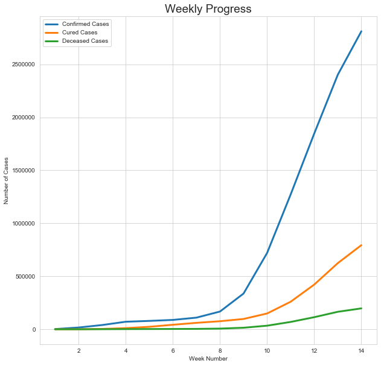

```python
plt.figure(figsize = (10,10))
plt.plot(week_num,weekwise_con,linewidth = 3,label="Confirmed Cases")
plt.plot(week_num,weekwise_cure,linewidth = 3,label="Cured Cases")
plt.plot(week_num,weekwise_death,linewidth = 3,label="Deceased Cases")
plt.xlabel("Week Number")
plt.ylabel("Number of Cases")
plt.legend()
plt.title("Weekly Progress",fontsize=19);
```

1. The Subplots provide the weekly status of Confirmed, Cured and Deceased cases seperately

```
Weekly Progress
```

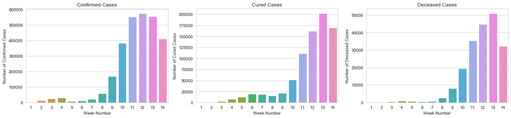

```python
fig,(ax1,ax2,ax3) = plt.subplots(1,3,figsize=(20,4))
sns.barplot(x=week_num,y=pd.Series(weekwise_con).diff().fillna(0),ax=ax1)
sns.barplot(x=week_num,y=pd.Series(weekwise_cure).diff().fillna(0),ax=ax2)
sns.barplot(x=week_num,y=pd.Series(weekwise_death).diff().fillna(0),ax=ax3)
print("Weekly Progress")
ax1.set_xlabel("Week Number")
ax2.set_xlabel("Week Number")
ax3.set_xlabel("Week Number")
ax1.set_ylabel("Number of Confirmed Cases")
ax2.set_ylabel("Number of Cured Cases")
ax3.set_ylabel("Number of Deceased Cases")
ax1.set_title("Confirmed Cases")
ax2.set_title("Cured Cases")
ax3.set_title("Deceased Cases")
plt.show()
```

Calculating the average number of cases per day

```python
print("Average number of confirmed cases everyday",np.round(datewise["Confirmed"].diff().fillna(0).mean()))
print("Average number of cured cases everyday",np.round(datewise["Cured"].diff().fillna(0).mean()))
print("Average number of deceased cases everyday",np.round(datewise["Deceased"].diff().fillna(0).mean()))
```

```
Average number of confirmed cases everyday 29900.0
Average number of cured cases everyday 8442.0
Average number of deceased cases everyday 2097.0
```

1. Daily Increase in the Covid-19 cases

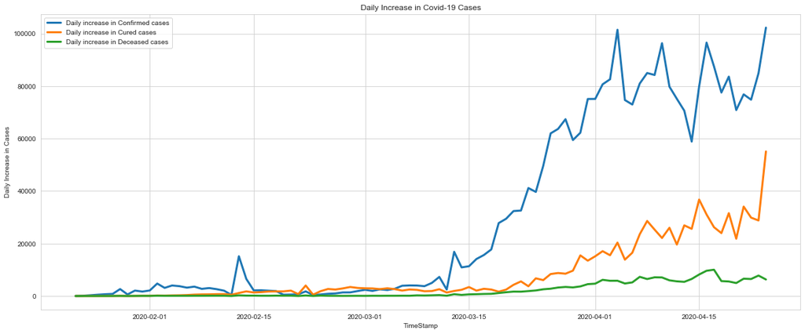

```python
plt.figure(figsize=(20,8))
plt.plot(datewise["Confirmed"].diff().fillna(0),label="Daily increase in Confirmed cases",linewidth=3)
plt.plot(datewise["Cured"].diff().fillna(0),label="Daily increase in Cured cases",linewidth=3)
plt.plot(datewise["Deceased"].diff().fillna(0),label="Daily increase in Deceased cases",linewidth=3)
plt.xlabel("TimeStamp")
plt.ylabel("Daily Increase in Cases")
plt.title("Daily Increase in Covid-19 Cases")
plt.legend()
plt.show()
```

Grouping the data based on the countries and Analysing the mortality rate and the recovery rate

```python
countrywise = df[df["Observation_Date"]==df["Observation_Date"].max()].groupby(["Country/Region"]).agg({"Confirmed":"sum","Cured":"sum","Deceased":"sum"}).sort_values(["Confirmed"],ascending=False)
countrywise["Mortality"] = (countrywise["Deceased"]/countrywise["Confirmed"])*100
countrywise["Recovery"] = (countrywise["Cured"]/countrywise["Confirmed"])*100
```

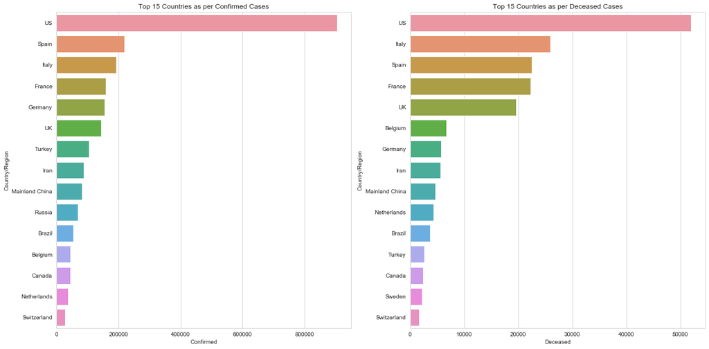

```python
fig,(ax1,ax2) = plt.subplots(1,2,figsize=(20,10))
top15con = countrywise.sort_values(["Confirmed"],ascending=False).head(15)
top15death = countrywise.sort_values(["Deceased"],ascending=False).head(15)
sns.barplot(x=top15con["Confirmed"],y=top15con.index,ax=ax1)
sns.barplot(x=top15death["Deceased"],y=top15death.index,ax=ax2)
ax1.set_title("Top 15 Countries as per Confirmed Cases")
ax2.set_title("Top 15 Countries as per Deceased Cases")
plt.show()
```

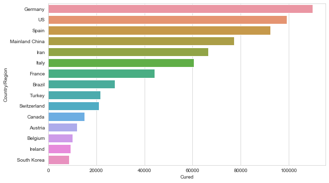

```python
plt.figure(figsize=(10,6))
top15death = countrywise.sort_values(["Cured"],ascending=False).head(15)
sns.barplot(x=top15death["Cured"],y=top15death.index)
ax2.set_title("Top 15 Countries as per Recovered Cases")
plt.show()
```

## Countrywise Analysis - India

From the entire dataset, data from India is grouped and analysed

```python
India = df[df["Country/Region"]=='India']
datewise_India = India.groupby(["Observation_Date"]).agg({"Confirmed":"sum","Cured":"sum","Deceased":"sum"})
print(datewise_India.iloc[-1])
print("Total Active Cases",datewise_India["Confirmed"].iloc[-1]-datewise_India["Cured"].iloc[-1]-datewise_India["Deceased"].iloc[-1])
print("Total Closed Cases",datewise_India["Cured"].iloc[-1]+datewise_India["Deceased"].iloc[-1])
```

```
Confirmed    24530
Cured         5498
Deceased       780
Name: 2020-04-24 00:00:00, dtype: int64
Total Active Cases 18252
Total Closed Cases 6278
```

Calculating the weekly progress in tha data

```python
datewise_India["WeekofYear"] = datewise_India.index.weekofyear
week_num_India = []
weekwise_con_India = []
weekwise_cure_India = []
weekwise_death_India = []

w = 1
for i in list(datewise_India["WeekofYear"].unique()):
    weekwise_con_India.append(datewise_India[datewise_India["WeekofYear"]==i]["Confirmed"].iloc[-1])
    weekwise_cure_India.append(datewise_India[datewise_India["WeekofYear"]==i]["Cured"].iloc[-1])
    weekwise_death_India.append(datewise_India[datewise_India["WeekofYear"]==i]["Deceased"].iloc[-1])
    week_num_India.append(w)
    w = w+1
```

1. The graph represents the weekly progress of Covid-19 cases in India

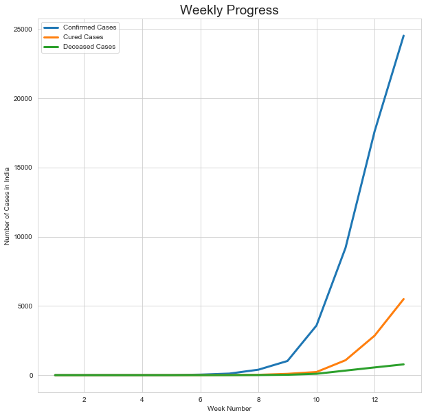

```python
plt.figure(figsize = (10,10))
plt.plot(week_num_India,weekwise_con_India,linewidth = 3,label="Confirmed Cases")
plt.plot(week_num_India,weekwise_cure_India,linewidth = 3,label="Cured Cases")
plt.plot(week_num_India,weekwise_death_India,linewidth = 3,label="Deceased Cases")
plt.xlabel("Week Number")
plt.ylabel("Number of Cases in India")
plt.legend()
plt.title("Weekly Progress",fontsize=19);
```

### Compairing the progress of Covid-19 in India with others countries like China,Italy,US and Spain where the Confirmed cases are high

Storing the maximum value in India to a variable

```python
max_India = datewise_India["Confirmed"].max()
```

From the entire dataset, data from other countries are grouped

```python
China = df[df["Country/Region"]=='Mainland China']
Italy = df[df["Country/Region"]=='Italy']
US = df[df["Country/Region"]=='US']
Spain = df[df["Country/Region"]=='Spain']
datewise_China = China.groupby(["Observation_Date"]).agg({"Confirmed":"sum","Cured":"sum","Deceased":"sum"})
datewise_Italy = Italy.groupby(["Observation_Date"]).agg({"Confirmed":"sum","Cured":"sum","Deceased":"sum"})
datewise_US = US.groupby(["Observation_Date"]).agg({"Confirmed":"sum","Cured":"sum","Deceased":"sum"})
datewise_Spain = Spain.groupby(["Observation_Date"]).agg({"Confirmed":"sum","Cured":"sum","Deceased":"sum"})
```

Checking the number of days it took to reach a specific value in each country

```python
print("In India, it took ",datewise_India[datewise_India["Confirmed"]>0].shape[0]," days to reach ",max_India," Confirmed cases.")
print("In China, it took ",datewise_China[(datewise_China["Confirmed"]>0) & (datewise_China["Confirmed"]<=max_India)].shape[0]," days to reach ",max_India," Confirmed cases.")
print("In Italy, it took ",datewise_Italy[(datewise_Italy["Confirmed"]>0) & (datewise_Italy["Confirmed"]<=max_India)].shape[0]," days to reach ",max_India," Confirmed cases.")
print("In US, it took ",datewise_US[(datewise_US["Confirmed"]>0) & (datewise_US["Confirmed"]<=max_India)].shape[0]," days to reach ",max_India," Confirmed cases.")
print("In Spain, it took ",datewise_Spain[(datewise_Spain["Confirmed"]>0) & (datewise_Spain["Confirmed"]<=max_India)].shape[0]," days to reach ",max_India," Confirmed cases.")
```

```
In India, it took  86  days to reach  24530  Confirmed cases.
In China, it took  14  days to reach  24530  Confirmed cases.
In Italy, it took  44  days to reach  24530  Confirmed cases.
In US, it took  59  days to reach  24530  Confirmed cases.
In Spain, it took  49  days to reach  24530  Confirmed cases.
```

## Modelling the data

Splitting the data for testing and training

```python
datewise["Days_Since"] = datewise.index - datewise.index[0]
datewise["Days_Since"] = datewise["Days_Since"].dt.days
train_ml = datewise.iloc[:int(datewise.shape[0]*0.90)]
valid_ml = datewise.iloc[int(datewise.shape[0]*0.90):]
model_scores = []
```

Performing the Linear Regression and Support Vector Regression on the data

```python
from sklearn.linear_model import LinearRegression
from sklearn.svm import SVR

lin_reg = LinearRegression(normalize=True)
svm = SVR(C=1,degree=5,kernel="poly",epsilon=0.001)
lin_reg.fit(np.array(train_ml["Days_Since"]).reshape(-1,1),np.array(train_ml["Confirmed"]).reshape(-1,1))
svm.fit(np.array(train_ml["Days_Since"]).reshape(-1,1),np.array(train_ml["Confirmed"]).reshape(-1,1))
```

```
SVR(C=1, degree=5, epsilon=0.001, kernel='poly')
```

Predicting the model performance on the test data

```python
prediction_lr = lin_reg.predict(np.array(valid_ml["Days_Since"]).reshape(-1,1))
prediction_svm = svm.predict(np.array(valid_ml["Days_Since"]).reshape(-1,1))
```

Predicting the No. of cases for the next 25 days

```python
new_date =[]
new_prediction_lr = []
new_prediction_svm = []
for i in range(1,26):
    new_date.append(datewise.index[-1]+timedelta(days=i))
    new_prediction_lr.append(lin_reg.predict(np.array(datewise["Days_Since"].max()+i).reshape(-1,1))[0][0])
    new_prediction_svm.append(svm.predict(np.array(datewise["Days_Since"].max()+i).reshape(-1,1))[0])
pd.set_option("display.float_format",lambda x: "%.f" % x)
model_pred = pd.DataFrame(zip(new_date,new_prediction_lr,new_prediction_svm),columns=["Dates","Linear_Regression","Support_Vector_Regression"])
model_pred
```

|  | Dates | Linear_Regression | Support_Vector_Regression |
| --- | --- | --- | --- |
| 0 | 2020-04-25 | 1309207 | 3553876 |
| 1 | 2020-04-26 | 1327070 | 3744948 |
| 2 | 2020-04-27 | 1344933 | 3944238 |
| 3 | 2020-04-28 | 1362796 | 4152006 |
| 4 | 2020-04-29 | 1380659 | 4368521 |
| 5 | 2020-04-30 | 1398522 | 4594056 |
| 6 | 2020-05-01 | 1416385 | 4828891 |
| 7 | 2020-05-02 | 1434248 | 5073308 |
| 8 | 2020-05-03 | 1452111 | 5327600 |
| 9 | 2020-05-04 | 1469974 | 5592062 |
| 10 | 2020-05-05 | 1487837 | 5866996 |
| 11 | 2020-05-06 | 1505700 | 6152710 |
| 12 | 2020-05-07 | 1523563 | 6449519 |
| 13 | 2020-05-08 | 1541426 | 6757741 |
| 14 | 2020-05-09 | 1559288 | 7077704 |
| 15 | 2020-05-10 | 1577151 | 7409739 |
| 16 | 2020-05-11 | 1595014 | 7754186 |
| 17 | 2020-05-12 | 1612877 | 8111388 |
| 18 | 2020-05-13 | 1630740 | 8481696 |
| 19 | 2020-05-14 | 1648603 | 8865469 |
| 20 | 2020-05-15 | 1666466 | 9263070 |
| 21 | 2020-05-16 | 1684329 | 9674869 |
| 22 | 2020-05-17 | 1702192 | 10101243 |
| 23 | 2020-05-18 | 1720055 | 10542577 |
| 24 | 2020-05-19 | 1737918 | 10999259 |

## Time Series Analysis

Splitting the data into training and testing data

```python
model_train = datewise.iloc[:int(datewise.shape[0]*0.85)]
valid = datewise.iloc[int(datewise.shape[0]*0.85):]
```

Using Holt Model to forecast the values. Fitting the train data into the model and forecasting the values for the test data

```python
from statsmodels.tsa.api import Holt
holt = Holt(np.asarray(model_train["Confirmed"])).fit(smoothing_level = 1.4,smoothing_slope = 0.2)
y_pred = valid.copy()
y_pred["Holt"] = holt.forecast(len(valid))
```

Forecasting the model for the next 25 days

```python
holt_new = []
holt_new_pred = []
for i in range(1,26):
    holt_new.append(datewise.index[-1]+timedelta(days=i))
    holt_new_pred.append(holt.forecast((len(valid)+i))[-1])
model_pred["Holts_Linear_Model"] = holt_new_pred
model_pred.head(10)
```

|  | Dates | Linear_Regression | Support_Vector_Regression | Holts_Linear_Model |
| --- | --- | --- | --- | --- |
| 0 | 2020-04-25 | 1309207 | 3553876 | 2855246 |
| 1 | 2020-04-26 | 1327070 | 3744948 | 2933902 |
| 2 | 2020-04-27 | 1344933 | 3944238 | 3012558 |
| 3 | 2020-04-28 | 1362796 | 4152006 | 3091214 |
| 4 | 2020-04-29 | 1380659 | 4368521 | 3169870 |
| 5 | 2020-04-30 | 1398522 | 4594056 | 3248526 |
| 6 | 2020-05-01 | 1416385 | 4828891 | 3327182 |
| 7 | 2020-05-02 | 1434248 | 5073308 | 3405838 |
| 8 | 2020-05-03 | 1452111 | 5327600 | 3484494 |
| 9 | 2020-05-04 | 1469974 | 5592062 | 3563150 |